# Introduntion to Matplotlib

Rajesh Majumder

April 7, 2023

Matplotlib is a plotting library for the Python programming language and its numerical mathematics extension NumPy. It provides an object-oriented API for embedding plots into applications using general-purpose GUI toolkits like Tkinter, wxPython, Qt, or GTK+.

Some of the major Pros of Matplotlib are:

- Generally easy to get started for simple plots.
- Support for custom labels and texts
- Great control of easy element in a figure
- High-quality output in many formats
- Very customizable in general

## Installation of Matplotlib

Install it using this command:(*write the command on the command python command prompt/ ANACONDA prompt*)

`pip install matplotlib`

or

`conda install matplotlib`

## Checking Matplotlib Version

The version string is stored under `__version__` attribute.

```python
import matplotlib as mat
print(mat.__version__)
```

```
3.5.2
```

Most of the Matplotlib utilities lies under the `pyplot` submodule, and are usually imported under the `plt` alias:

```python
import matplotlib.pyplot as plt
```

**Example:** *Draw a line in a diagram from position (0,0) to position (6,250):*

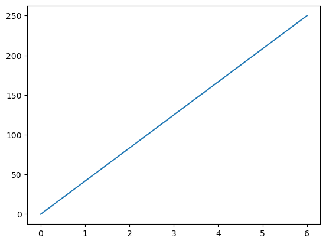

```python
import numpy as np

xpoints = np.array([0, 6])      ## Data
ypoints = np.array([0, 250])

plt.plot(xpoints, ypoints)     ## Plotting Function

plt.show()                    ## To show the plot
```

## How to display our plots ?

Note that, To show a plot, `plot.show()` function is used. But, there is an alternative :

- If we are using Matplotlib from within a script, the function `plt.show()` is our friend. `plt.show()` starts an event loop, looks for all currently active figure objects, and opens one or more interactive windows that display your figure or figures.
- If we are using Jupyter NoteBook, we can use the **`%matplotlib`** magic command after starting Notebook. At this point, any plt plot command will cause a figure window to open, and further commands can be run to update the plot. `plt.show()` in Matplotlib mode is not required.

## Saing Figures to File

To save a figure in PNG, or JPEG we use the function **`savefig()`**

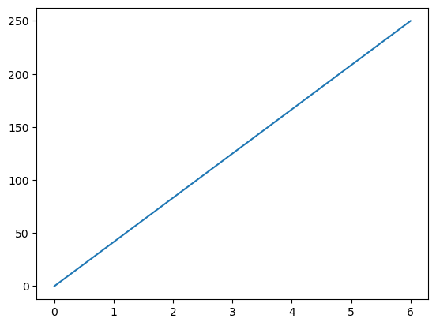

```python
xpoints = np.array([0, 6])      ## Data
ypoints = np.array([0, 250])

plt.plot(xpoints, ypoints)     ## Plotting Function

plt.savefig("Test.jpeg")
```

## Scatter Plot

```python
x= np.arange(start=0,stop=10)    ##  np.arange() => Return evenly spaced values within a given interval
print("x:",x,"\n")
y= np.arange(start=11,stop=21)
print("y:",y,"\n")
```

```
x: [0 1 2 3 4 5 6 7 8 9]

y: [11 12 13 14 15 16 17 18 19 20]
```

### (1) Plotting Scatter plot

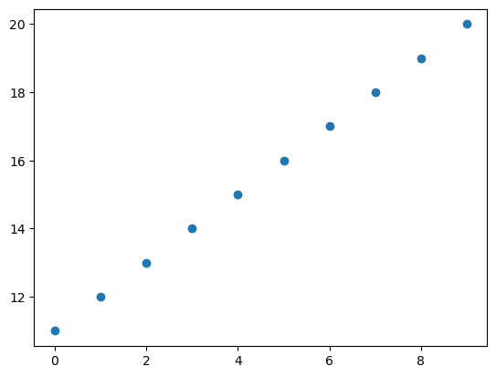

```python
plt.scatter(x,y)
```

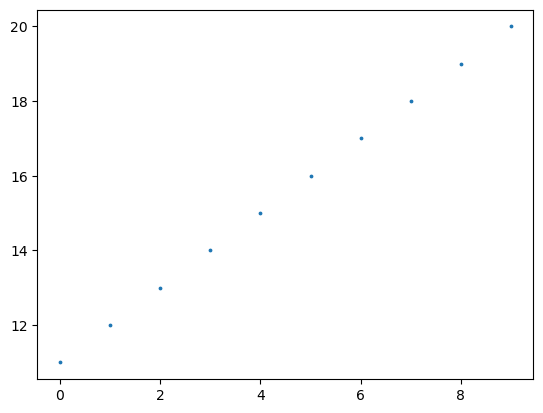

```python
plt.scatter(x,y,s=3)  # s=> shape parameter
```

### (3) Changing the color of the points

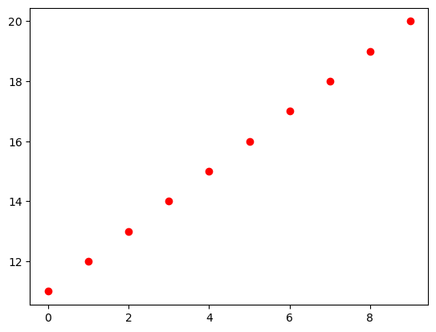

```python
plt.scatter(x,y,c='r')  # c=> color parameter
```

### (4) Adding Axis Labels and Title

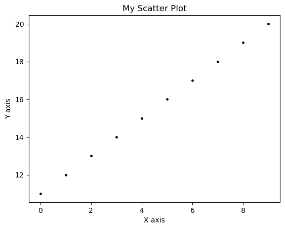

```python
plt.scatter(x,y,c="black",s=6)
plt.xlabel("X axis")
plt.ylabel("Y axis")
plt.title("My Scatter Plot")
```

### (5) Add labels to points

**`plt.annotate(<label>, <coords>)`** using the value itself as label:

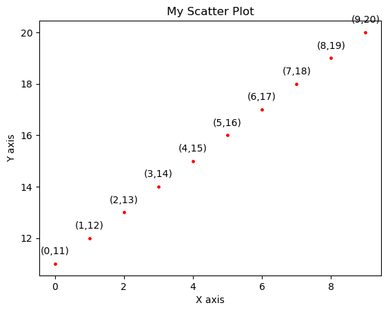

```python
plt.scatter(x,y,c="r",s=6)
plt.xlabel("X axis")
plt.ylabel("Y axis")
plt.title("My Scatter Plot")

## Creating Labels:
labs=[]
for i in range(len(x)):
    labs.append('('+str(x[i])+','+str(y[i])+')') ## Levels of the points
    plt.annotate(labs[i], # text
                 (x[i],y[i]), # coordinates to position the label
                textcoords="offset points", # how to position the text
                xytext=(0,10), # distance from text to points (x,y),
                ha='center') # horizontal alignment can be left, right or center
```

### (6) Remove Axis Labels

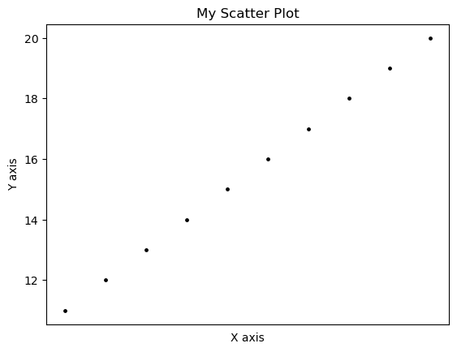

```python
plt.scatter(x,y,c="black",s=6)
plt.xlabel("X axis")
plt.ylabel("Y axis")
plt.xticks(ticks=[])   ## Removing X-axis ticks/labels
plt.title("My Scatter Plot")
```

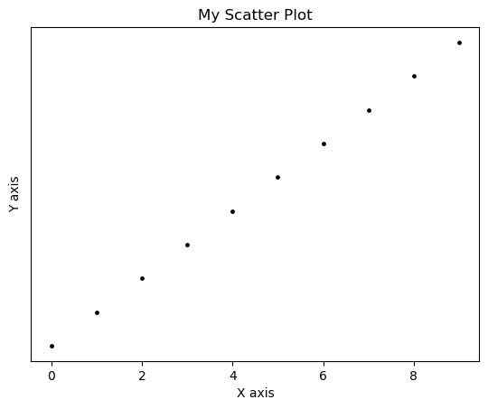

```python
plt.scatter(x,y,c="black",s=6)
plt.xlabel("X axis")
plt.ylabel("Y axis")
plt.yticks(ticks=[])   ## Removing Y-axis ticks/labels
plt.title("My Scatter Plot")
```

### (7) Multiple Plots

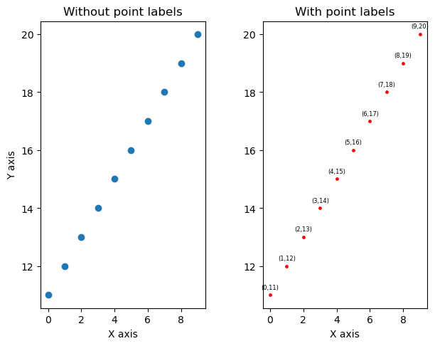

```python
## 1st Plot:
plt.subplot(1,2,1)  ## Creating ploting region. 1st plot of the  (1x2) ploting region
plt.scatter(x,y)
plt.xlabel("X axis")
plt.ylabel("Y axis")
plt.title("Without point labels")

# 2nd Plot:
plt.subplot(1,2,2) ## Creating ploting region. 1st plot of the  (1x2) ploting region
plt.scatter(x,y,c="r",s=6)
plt.xlabel("X axis")
plt.title("With point labels")
labs=[]
for i in range(len(x)):
    labs.append('('+str(x[i])+','+str(y[i])+')')
    plt.annotate(labs[i],(x[i],y[i]),textcoords="offset points",xytext=(0,6),ha='center',fontsize=6)

## Adjustment of subplot layout
plt.subplots_adjust(top=0.92, bottom=0.08, left=0.10, right=0.95, hspace=0.25,
                    wspace=0.35)
```

## Line Diagram

### (1) Plotting Line diagram

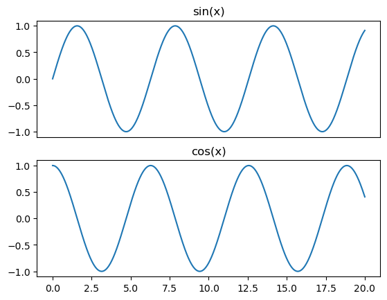

```python
x= np.linspace(0,20,1000)
y1= np.sin(x)
y2= np.cos(x)

plt.subplot(2,1,1)
plt.plot(x,y1)
plt.xticks(ticks=[]) ## Remove the x-axis ticks and labels.
plt.title("sin(x)")

#Plotting 2nd line
plt.subplot(2,1,2)
plt.plot(x,y2)
plt.title("cos(x)")
```

### (2) Changing Color, line type, line width

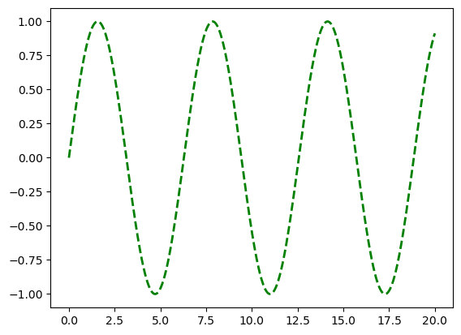

```python
plt.plot(x,y1,'g',linestyle="dashed",linewidth=2)  ## alternatively, linestyle="--"

## See the help for more details
```

### (3) Multiple lines one same scale

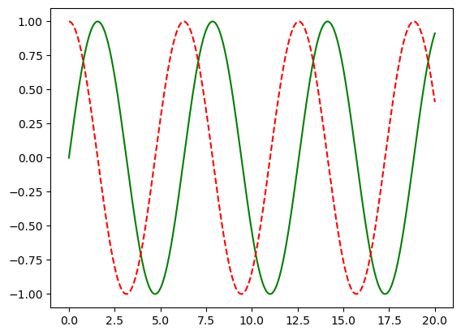

```python
plt.plot(x,y1,'-g',label='sin(x)')
plt.plot(x,y2,'--r',label='cos(x)')
```

### (4) Add legend

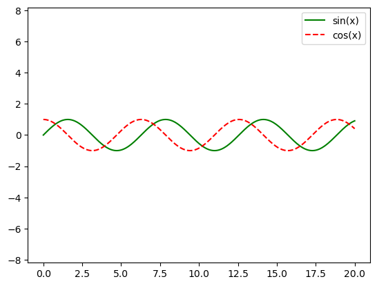

```python
plt.plot(x,y1,'-g',label='sin(x)')
plt.plot(x,y2,'--r',label='cos(x)')
plt.axis('equal')
plt.legend()
```

### (5) Changing axes limits

```
(0.0, 13.0)
```

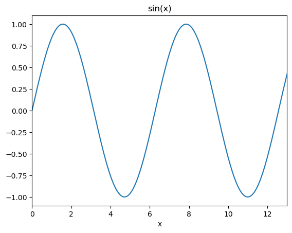

```python
plt.plot(x,y1)
plt.title("sin(x)")
plt.xlabel("x")
plt.xlim(0,13)  ## Changing the x limit from [0,20]-> [0,13]
```

## Bar plot

```python
## Creating Data
import pandas as pd
Country_data= pd.DataFrame(np.random.choice(["India","Australia","USA","UK","Germany","China","Russia"],size=100,replace=True))
Country_data= pd.DataFrame({'Country':list(set(Country_data[0])),'Freq':list(Country_data.value_counts())},index=None)
Country_data
```

|  | Country | Freq |
| --- | --- | --- |
| 0 | USA | 20 |
| 1 | Russia | 17 |
| 2 | Australia | 16 |
| 3 | Germany | 16 |
| 4 | India | 13 |
| 5 | UK | 10 |
| 6 | China | 8 |

### (1) Plotting Bar diagram

[figure not shown]

```python
plt.bar(Country_data['Country'],Country_data['Freq'])
plt.xlabel("Country Name")
plt.ylabel("Frequency")
plt.title("Country Data")
```

### (2) Changing color and bin width

[figure not shown]

```python
plt.bar(x=Country_data['Country'],height= Country_data['Freq'],width=0.4,color ='orange')
plt.xlabel("Country Name")
plt.ylabel("Frequency")
plt.title("Country Data")
```

### (3) Horizontal Bar diagram

[figure not shown]

```python
plt.barh(y=Country_data['Country'],width= Country_data['Freq'],height=0.4,color ='orange')
plt.xlabel("Frequency")
plt.ylabel("Country Name")
plt.title("Country Data")
```

### (4) Add Text to the bars.

[figure not shown]

```python
## 1st Plot:
plt.subplot(1,2,2)
plt.bar(x=Country_data['Country'],height= Country_data['Freq'],width=0.4,color ='orange')
plt.xlabel("Country Name")
plt.ylabel("Frequency")
plt.title("Country Data")
x_coordinate= np.arange(0,len(Country_data["Country"].values))
y_coordinate= Country_data["Freq"].values
labs=[]
for i in range(Country_data.shape[0]):
    labs.append(str(Country_data["Freq"].values[i]))
    plt.annotate(labs[i],(x_coordinate[i],y_coordinate[i]),textcoords="offset points",xytext=(0,3),ha='center',fontsize=6)


## 2nd Plot:
plt.subplot(1,2,1)
plt.barh(y=Country_data['Country'],width= Country_data['Freq'],height=0.4,color ='maroon')
plt.xlabel("Frequency")
plt.ylabel("Country Name")
plt.title("Country Data")
y_coordinate= np.arange(0,len(Country_data["Country"].values))
x_coordinate= Country_data["Freq"].values+0.5
labs=[]
for i in range(Country_data.shape[0]):
    labs.append(str(Country_data["Freq"].values[i]))
    plt.annotate(labs[i],(x_coordinate[i],y_coordinate[i]),textcoords="offset points",xytext=(0,3),ha='center',fontsize=6)


## Adjustment of subplot layout
plt.subplots_adjust(top=0.92, bottom=0.08, left=0.10, right=0.95, hspace=0.25,
                    wspace=0.35)
```

### (5) Multiple Bar plots

#### Creating dataframe

```python
df = pd.DataFrame({
    'Name': ['Arnab','Mainak','Kunal','Sourav'],
    'Age': [45,38,60,89],
    'Height(in cm)': [150, 180, 160, 170]
})

df
```

|  | Name | Age | Height(in cm) |
| --- | --- | --- | --- |
| 0 | Arnab | 45 | 150 |
| 1 | Mainak | 38 | 180 |
| 2 | Kunal | 60 | 160 |
| 3 | Sourav | 89 | 170 |

#### Method 1: Providing multiple columns in y parameter

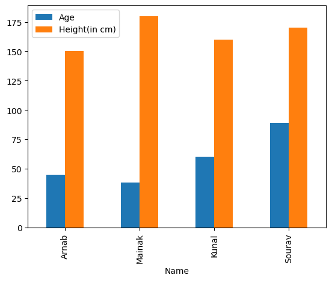

```python
# plotting graph
df.plot(x="Name", y=["Age", "Height(in cm)"], kind="bar")
```

#### Method 2: By plotting on the same axis

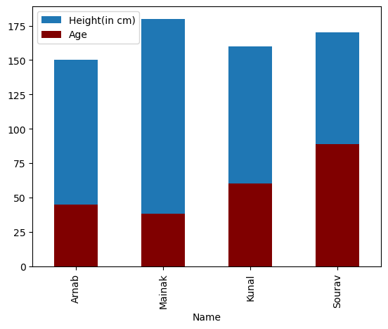

```python
# plotting Height
ax = df.plot(x="Name", y="Height(in cm)", kind="bar")
# plotting age on the same axis
df.plot(x="Name", y="Age", kind="bar", ax=ax, color="maroon")
```

## Boxplot

[output not shown]

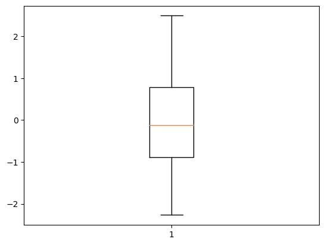

```python
plt.boxplot(x=np.random.normal(0,1,100))
```

#### Add color

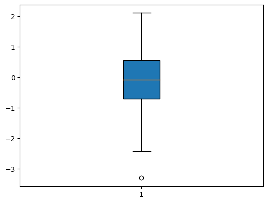

```python
plt.boxplot(x=np.random.normal(0,1,100),patch_artist=True)
plt.show()
```

#### Multiple Boxplot

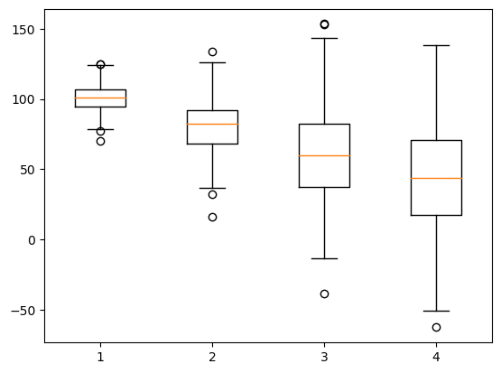

```python
np.random.seed(10)

dataSet1 = np.random.normal(100, 10, 220)
dataSet2 = np.random.normal(80, 20, 200)
dataSet3 = np.random.normal(60, 35, 220)
dataSet4 = np.random.normal(50, 40, 200)
dataSet = [dataSet1, dataSet2, dataSet3, dataSet4]


plt.boxplot(dataSet)
plt.show()
```

#### Rotatig the axis

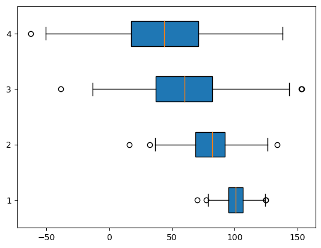

```python
np.random.seed(10)

dataSet1 = np.random.normal(100, 10, 220)
dataSet2 = np.random.normal(80, 20, 200)
dataSet3 = np.random.normal(60, 35, 220)
dataSet4 = np.random.normal(50, 40, 200)
dataSet = [dataSet1, dataSet2, dataSet3, dataSet4]


plt.boxplot(dataSet,vert=False,patch_artist=True)
plt.show()
```

#### Some Customuization in boxplot

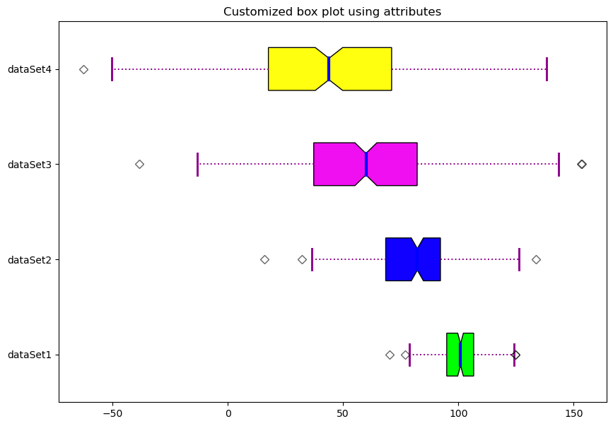

```python
np.random.seed(10)
dataSet1 = np.random.normal(100, 10, 220)
dataSet2 = np.random.normal(80, 20, 200)
dataSet3 = np.random.normal(60, 35, 220)
dataSet4 = np.random.normal(50, 40, 200)
dataSet = [dataSet1, dataSet2, dataSet3, dataSet4]

figure = plt.figure(figsize =(10, 7))
ax = figure.add_subplot(111)
bp = ax.boxplot(dataSet, patch_artist = True,notch ='True', vert = 0)
colors = ['#00FF00','#0F00FF', '#F00FF0','#FFFF0F']
for patch, color in zip(bp['boxes'], colors):
    patch.set_facecolor(color)
for whisker in bp['whiskers']:
    whisker.set(color ='#8E008B',linewidth = 1.4,linestyle =":")
for cap in bp['caps']:
    cap.set(color ='#8E008B',linewidth = 2.1)
for median in bp['medians']:
    median.set(color ='blue',linewidth = 3)
for flier in bp['fliers']:
    flier.set(marker ='D',color ='#d7298c',alpha = 0.6)
ax.set_yticklabels(['dataSet1', 'dataSet2','dataSet3', 'dataSet4'])
plt.title("Customized box plot using attributes")
ax.get_xaxis().tick_bottom()
ax.get_yaxis().tick_left()
```

## Pie Chart

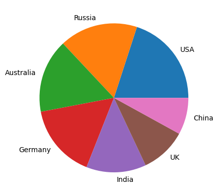

```python
## Preparing Data
plt.pie(x=Country_data['Freq'],labels=Country_data['Country'])
plt.show()
```

#### Add Legend

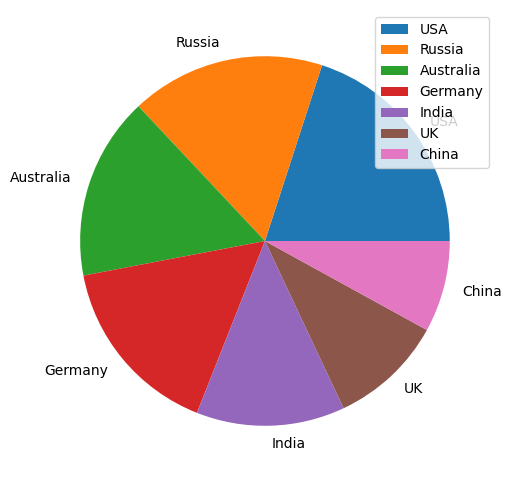

```python
plt.figure(figsize=(20,6))
plt.pie(x=Country_data['Freq'],labels=Country_data['Country'])
plt.legend()
plt.show()
```

## Histogram

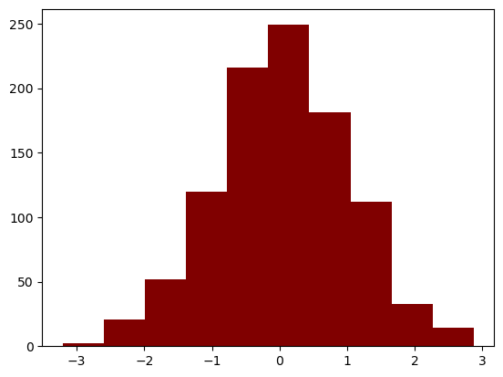

```python
## Preparing Data
X= np.random.normal(loc=0,scale=1,size=1000)

## Histogram
plt.hist(X,color="maroon")
plt.show()
```

#### Overlapping two Histograms

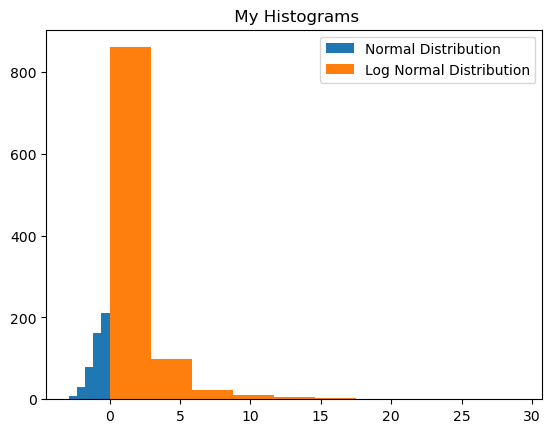

```python
## Data 1: X1 From N(0,1)
X1= np.random.normal(loc=0,scale=1,size=1000)

## Data 2: X2 From Log Normal(0,1)
X2= np.random.lognormal(mean=0,sigma=1,size=1000)

## Plotting Histograms:

plt.hist(X1,label="Normal Distribution")

plt.hist(X2,label="Log Normal Distribution")

plt.legend(loc="upper right")

plt.title(label=" My Histograms")
plt.show()
```

#### Transparency

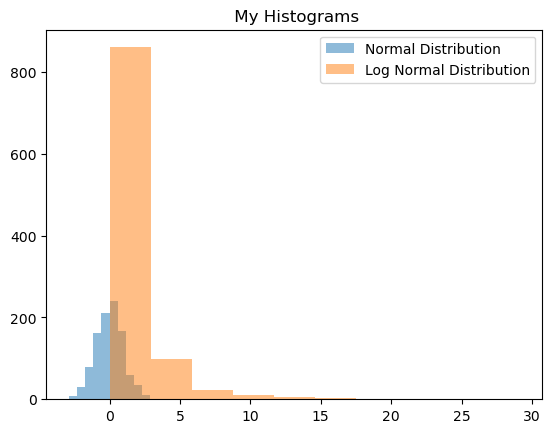

```python
## Plotting Histograms:

plt.hist(X1,label="Normal Distribution",alpha=0.5)

plt.hist(X2,label="Log Normal Distribution",alpha=0.5)

plt.legend(loc="upper right")

plt.title(label=" My Histograms")
plt.show()
```

## Error Bars

```
<ErrorbarContainer object of 3 artists>
```

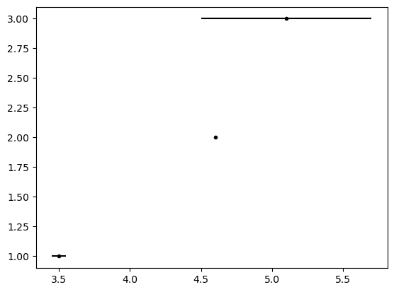

```python
## Preparing Data
Mean= [3.5,4.6,5.1]
se= [0.05,0.005,0.6]
y=[1,2,3]

plt.errorbar(Mean,y,xerr=se,fmt=".k",)
```